# Analysis of Social Networks Use Among Adults in The US

2020-09-07

# General Social Survey (GSS)

The [General Social Survey (GSS)](http://www.gss.norc.org/) gathers data on American society in order to monitor and explain trends in attitudes, behaviours, and attributes. Many trends have been tracked for decades, so one can see the evolution of attitudes, etc in American Society.

Using data from the **2016 GSS sample data** we are attempting to estimate the values of *population parameters* of interest about US adults. The GSS sample data file has 2867 observations of 935 variables, but we are only interested in very few of these variables hence a smaller file is chosen.

Using vroom function we are able to read the csv file with necessary data in a relatively quick way

```r
gss <- vroom::vroom(here::here("data", "smallgss2016.csv"),
                    #choosing the file and reading it
                na = c("", "Don't know",
                       "No answer", "Not applicable"))
#setting the answers which will further be considered as NA
```

We exclude some answers such as “Don’t know”, “No answer”, “Not applicable” and treat them as missing data

The goal is to create 95% confidence intervals for population parameters. Let’s quickly describe the variables that the dataset provides:

- hours and minutes spent on email weekly. The responses to these questions are recorded in the `emailhr` and `emailmin` variables. For example, if the response is 2.50 hours, this would be recorded as emailhr = 2 and emailmin = 30.
- `snapchat`, `instagrm`, `twitter`: whether respondents used these social media in 2016
- `sex`: Female - Male
- `degree`: highest education level attained

## Instagram and Snapchat, by sex

The ultimate goal here is to try and estimate the *population* proportion of Snapchat or Instagram users in 2016

First step is creating a new variable, `snap_insta` that is *Yes* if the respondent reported using any of Snapchat (`snapchat`) or Instagram (`instagrm`), and *No* if not. It takes value *NA* If the recorded value was *NA* for both of these questions

```r
gss_new<-gss %>%
  na_if("NA") %>% #this allows R to treat cells with "NA" as missing data
  mutate(
    snap_insta=ifelse(snapchat=="NA"&instagrm=="NA", #creating new variable
                      "NA",
          #if both snapchat and instagram take value "NA", then snap_insta also takes value "NA"
                      ifelse(snapchat=="Yes"|instagrm=="Yes",
                             "Yes",
                             "No")))
#otherwise it takes value Yes (if either snapchat or instagram is used) or No
#if the latter is not the case
```

Next step is to calculate the proportion of Yes’s for `snap_insta` among those who answered the question. We have provided calculation either way: -separately for men and women -combined for men and women

```r
gss_newer_sep<-gss_new%>%
  filter(!is.na(snap_insta)) %>% #excluding missing data
  group_by(sex) %>% #grouping by sex to attain separate proportions for men and women
  mutate(user=ifelse(snap_insta=="Yes", 1, 0)) %>% #creating dummy variable which takes value 1 if snap_insta variable   is equal to "Yes" and 0 otherwise for men and women separately
  summarise(total=length(user), answer_yes=sum(user)) %>% #counting how many responded in total and how many responded   "Yes" among men and women
  mutate(prop=answer_yes/total) #counting the proportion of "Yes's" for snap_insta among those who answered separ

gss_newer_sep
```

```
## # A tibble: 2 x 4
##   sex    total answer_yes  prop
##   <chr>  <int>      <dbl> <dbl>
## 1 Female   769        322 0.419
## 2 Male     603        192 0.318
```

```r
gss_newer<-gss_new%>%
  filter(!is.na(snap_insta)) %>% #excluding missing data
  mutate(user=ifelse(snap_insta=="Yes", 1, 0)) %>%
  #creating dummy variable which takes value 1 if snap_insta variable is equal to "Yes"
  #and 0 otherwise
  summarise(total=length(user), answer_yes=sum(user)) %>% #counting how many responded
  #in total and how many responded "Yes" by counting the sum of 1's in the dummy created earlier
  mutate(prop=answer_yes/total) #counting the proportion of "Yes's" for snap_insta
  #among those who answered

gss_newer
```

```
## # A tibble: 1 x 3
##   total answer_yes  prop
##   <int>      <dbl> <dbl>
## 1  1372        514 0.375
```

1. Now we construct 95% CIs for men and women who used either Snapchat or Instagram and repeat this for combined sample (both men and women)

```r
gss_newer_sep %>%
  group_by(sex) %>% #grouping by sex to see for who the interval is calculated for
  summarise(lower_95=prop-qt(0.975, total-1)*sqrt((prop*(1-prop))/total),
            upper_95=prop+qt(0.975, total-1)*sqrt((prop*(1-prop))/total))
```

```
## # A tibble: 2 x 3
##   sex    lower_95 upper_95
##   <chr>     <dbl>    <dbl>
## 1 Female    0.384    0.454
## 2 Male      0.281    0.356
```

```r
#using CI formula for proportion

gss_newer %>%
  summarise(lower_95=prop-qt(0.975, total-1)*sqrt((prop*(1-prop))/total),
            upper_95=prop+qt(0.975, total-1)*sqrt((prop*(1-prop))/total))
```

```
## # A tibble: 1 x 2
##   lower_95 upper_95
##      <dbl>    <dbl>
## 1    0.349    0.400
```

```r
#using CI formula for proportion
```

Some interpretation is also required. For the separate intervals we have it as follows: We are 95% confident that *population proportion* of females that used instagram or snapchat is in the interval between 0.384 and 0.454. We are 95% confident that *population proportion* of males that used instagram or snapchat is in the interval between 0.281 and 0.356.

So, there is certain tendency that lower proportion of males tend to use social networks.

## Twitter, by education level

Now we move on to estimation of the *population* proportion of Twitter users by education level in 2016

First of all, we turn `degree` variable from a character variable into a factor variable. We ensure that the order is the correct one by setting levels as R sorts alphabetically by default. The order that we used is ascending order of years of education, are Lt high school, High School, Junior college, Bachelor, Graduate.

```r
gss_clear<-gss %>%
  na_if("NA") %>% #making sure that NA's are treated as missing values
  mutate(
        degree=factor(degree, levels=c("Lt high school",
                                       "High School", "Junior college",
                                       "Bachelor", "Graduate"))) %>%
  #denote degree as a factor variable with levels assigned in accordance to the above order
  filter(!is.na(degree)) #filtering out those missing values
class(gss_clear$degree) #checking if it works
```

```
## [1] "factor"
```

```r
str(gss_clear$degree) #showing the structure of the new variable format
```

```
##  Factor w/ 5 levels "Lt high school",..: 4 4 5 3 3 1 1 5 1 1 ...
```

We also create a new variable, `bachelor_graduate` that takes value *Yes* if the respondent has either a `Bachelor` or `Graduate` degree. But if the recorded value for either was NA, the value of the new variable is NA too.

```r
gss_bachelor_graduate<-gss_clear %>%
  mutate(
    bachelor_graduate=ifelse(degree=="",
                      #creating new variable which says "NA" if degree is "NA"
                      "",
                      ifelse(degree=="Bachelor"|degree=="Graduate",
                             "Yes",
                             "No")))
#if degree is not "NA" it takes value "Yes" given  that degree is either
#Bachelor or Graduate. If nothing mentioned before is the case, then the value is "No"
```

We now calculate the proportion of `bachelor_graduate` who do (Yes) and who don’t (No) use twitter.

```r
gss_bachelor_graduate %>%
  filter(!is.na(twitter)) %>% #filtering out missing values
  filter(bachelor_graduate=="Yes") %>% #choosing bachlors of graduates only
  group_by(twitter) %>% #group by twitter use
  summarise(count=n()) %>% #counting the number of thoes who use and does not
mutate(prop=count/sum(count))
```

```
## # A tibble: 2 x 3
##   twitter count  prop
##   <chr>   <int> <dbl>
## 1 No        375 0.767
## 2 Yes       114 0.233
```

1. Using the CI formula for proportions, please construct two 95% CIs for `bachelor_graduate` vs whether they use (Yes) and don’t (No) use twitter.

```r
gss_int<-gss_bachelor_graduate %>%
  filter(!is.na(twitter)) %>% #filtering out missing data
  filter(bachelor_graduate=="Yes") %>% #choosing only bachelors and graduates
  group_by(twitter) %>% #calculating for who use and do not use twitter
  summarise(count=n()) %>% #calculating the number of twitter users/not users
  mutate(total=sum(count)) %>% #finding total bachelors and graduates answered
  mutate(prop=count/total) #finding proportion

gss_int %>%
  group_by(twitter) %>% #grouping by the interval for twitter users and not twitter users
  summarise(lower_95=prop-qt(0.975, total-1)*sqrt((prop*(1-prop))/total),
            upper_95=prop+qt(0.975, total-1)*sqrt((prop*(1-prop))/total))
```

```
## # A tibble: 2 x 3
##   twitter lower_95 upper_95
##   <chr>      <dbl>    <dbl>
## 1 No         0.729    0.804
## 2 Yes        0.196    0.271
```

```r
#using CI formula for intervals
```

1. Do these two Confidence Intervals overlap?

## Email usage

We next proceed to estimation of the *population* parameter on time spent on email weekly

We created a new variable `email` that combines `emailhr` and `emailmin` to reports the number of minutes the respondents spend on email weekly.

```r
gss_email<-gss %>%
  na_if("NA") %>% #making sure R recognises "NA" as missing values
  mutate(email=as.numeric(emailhr)*60+as.numeric(emailmin))
#creating variable email to report weakly minutes spent on email

gss_email
```

```
## # A tibble: 2,867 x 8
##    emailmin emailhr snapchat instagrm twitter sex    degree         email
##    <chr>    <chr>   <chr>    <chr>    <chr>   <chr>  <chr>          <dbl>
##  1 0        12      <NA>     <NA>     <NA>    Male   Bachelor         720
##  2 30       0       No       No       No      Male   High school       30
##  3 <NA>     <NA>    No       No       No      Male   Bachelor          NA
##  4 10       0       <NA>     <NA>     <NA>    Female High school       10
##  5 <NA>     <NA>    Yes      Yes      No      Female Graduate          NA
##  6 0        2       No       Yes      No      Female Junior college   120
##  7 0        40      <NA>     <NA>     <NA>    Male   High school     2400
##  8 <NA>     <NA>    Yes      Yes      No      Female High school       NA
##  9 0        0       <NA>     <NA>     <NA>    Male   High school        0
## 10 <NA>     <NA>    No       No       No      Male   Junior college    NA
## # … with 2,857 more rows
```

Visualization of the distribution of this new variable is presented below. We calculate the mean and the median number of minutes respondents spend on email weekly. We next discuss which statistic is better to use in our case.

```r
gss_stat<-gss_email %>%
  select(email) %>% #choosing email variable
  filter(!is.na(email)) %>% #filtering out missing values
  summarise(mean=mean(email),median=median(email)) #calculating mean and median
gss_stat
```

```
## # A tibble: 1 x 2
##    mean median
##   <dbl>  <dbl>
## 1  417.    120
```

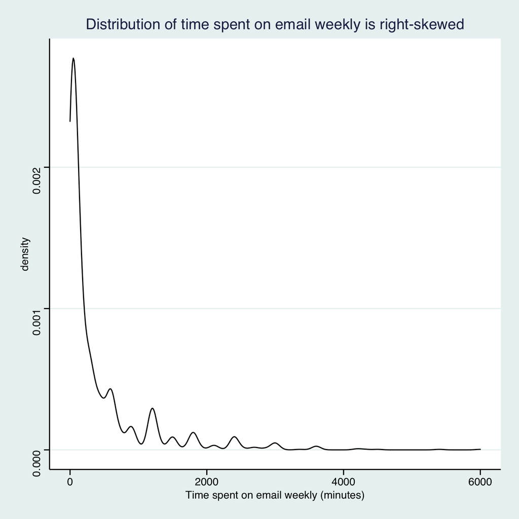

```r
gss_email %>%
  filter(!is.na(email)) %>% #filtering out missing values
ggplot(aes(x=email))+
  #building a plot with number of minutes spent on email weekly on the x-axis
  geom_density()+ #choosing to build a density plot
  labs(title="Distribution of time spent on email weekly is right-skewed")+ #title added
  xlab("Time spent on email weekly (minutes)")+ #x-axis label added
  theme_stata() #setting a theme
```

Distribution of the variable “email” allows to see that it is heavily right-skewed, which means that average (mean) will also tend to be so, as it is affected by the presence of outliers, which is definitely the case. So to better interpret the ‘typical’ time for Americans to spend on email, it is better not to rely on such obscure values but rather draw conclusions based on regular users. Hence, median is preferred (it is not affected by outliers).

Calculating a 95% bootstrap confidence interval for the mean amount of time Americans spend on email weekly.

```r
email_CI <- gss_email %>%
  filter(!is.na(email)) %>% #filtering out missing values
  specify(response = email) %>% #doing the necessary steps to build bootstrap interval
  generate(reps = 1000, type = "bootstrap") %>%
  calculate(stat = "mean") #choosing the mean as asked

percentile_CI <- email_CI %>%
  get_ci(level = 0.95, type = "percentile") #getting the interval

percentile_CI
```

```
## # A tibble: 1 x 2
##   lower_ci upper_ci
##      <dbl>    <dbl>
## 1     385.     449.
```

We have built 95% confidence interval, but let’s see what changes when confidence level increases up to 99%. All else equal, the higher the confidence level, the wider is the interval. This is very intuitive, as claiming about population parameter with higher certainty would require additional space for possible (but less likely) outcomes, that are not considered when the statement about population is made with lower confidence. Alternatively, this can be derived from the formula of CI for proportions.

Another way to address this question is to use data visualization

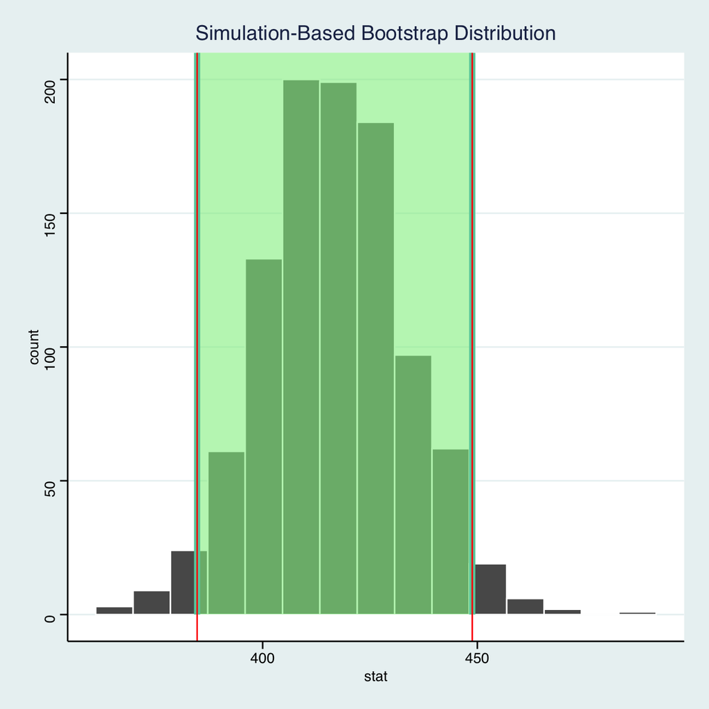

```r
visualize(email_CI) +
  shade_ci(endpoints = percentile_CI,fill = "light green")+
  geom_vline(xintercept = percentile_CI$lower_ci, colour = "red")+
  geom_vline(xintercept = percentile_CI$upper_ci, colour = "red")+
  theme_stata()
```

On this graph we can see the green area highlighting the bounds of 95% confidence interval.

```r
percentile_CI_99 <- email_CI %>%
  get_ci(level = 0.99, type = "percentile")

percentile_CI_99
```

```
## # A tibble: 1 x 2
##   lower_ci upper_ci
##      <dbl>    <dbl>
## 1     375.     462.
```

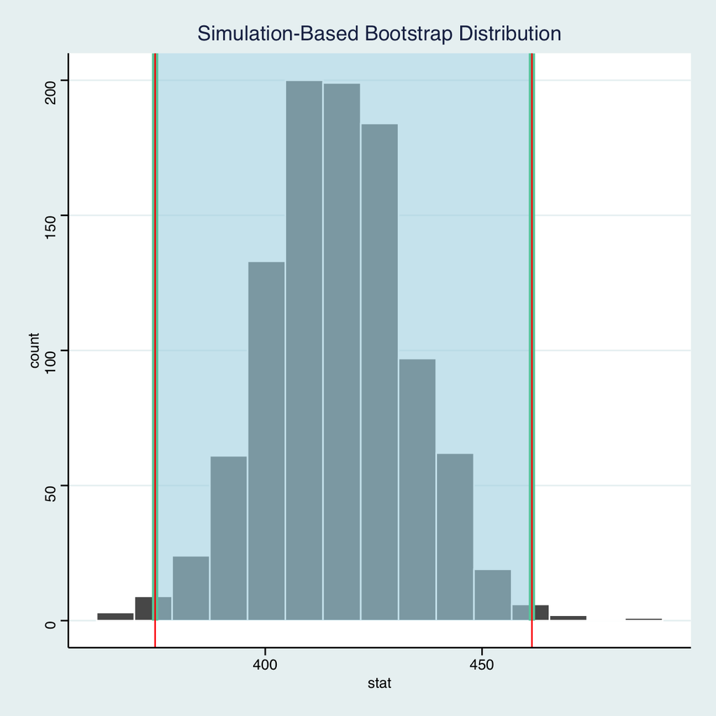

```r
visualize(email_CI) +
  shade_ci(endpoints = percentile_CI_99,fill = "light blue")+
  geom_vline(xintercept = percentile_CI_99$lower_ci, colour = "red")+
  geom_vline(xintercept = percentile_CI_99$upper_ci, colour = "red")+
  theme_stata()
```

Alternatively, this graph shows the bounds of the 99% CI highlighted by the blue area. In comparison to earlier diagram, it definitely is wider, as larger number of possible outcomes need to be considered to state with higher certainty.